# The R Toolkit

*Adapted from:*  
Data Science in Education Using R - Chapter 6  
https://datascienceineducation.com  
Data Science in a Box - Hello World!  
https://datasciencebox.com

# Today’s Agenda

**R Tools**

1. Numbers & Operators
2. Objects & Data
3. Functions & Arguments
4. Packages
5. RStudio Projects

**Bring it Together**

6. Project Setup
7. Exploring Data
8. Pipe Operator
9. Assignment vs. Equality
10. Object Naming

# NUMBERS & OPERATORS

type: section

Arithmetic, Logic, & Assignment

# R is a Calculator

Numbers and basic arithmetic operators (+ , - , *, /) behave as expected.

Type this in your console:

```r
2 + 3
```

You’ll get this:

```
[1] 5
```

Arithmetic Operators

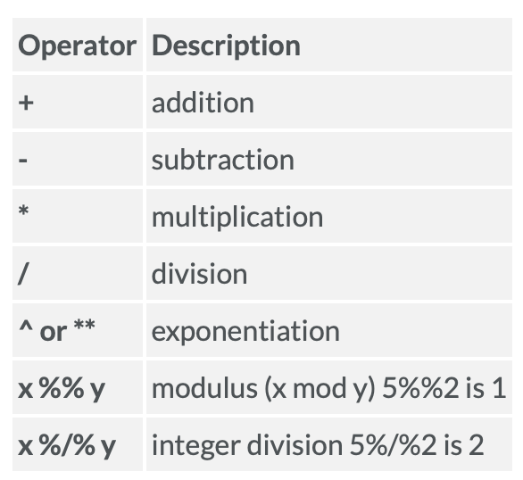

# R is Logical

R can also perform logical operations.

What happens when you type this in your console?

```r
5 > 3
```

Or this?

```r
5 == 3
```

What symbol seems to be missing? Or rather has been replaced?

Logical Operators

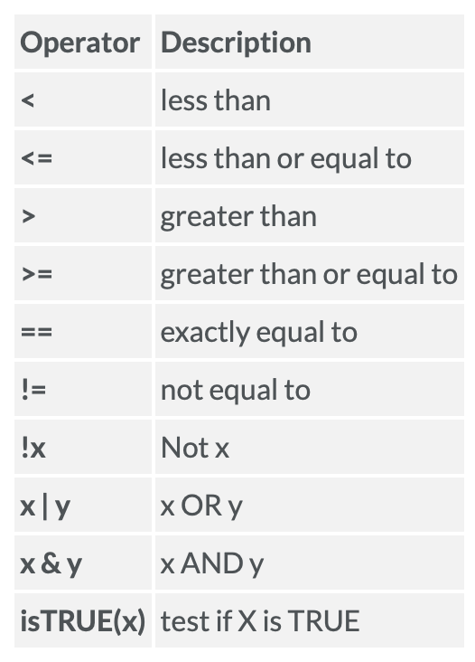

# The Assignment Operator(s)

**Bad Form**

```r
my_variable = 2 + 3

my_variable
```

```
[1] 5
```

**Good Form**

```r
my_dog <- "Howie"

my_dog
```

```
[1] "Howie"
```

# Other Essential Operator(s)

**The Dollar $ign** Used to select variables.

```r
trees$Height
```

[output not shown]

Now you try:  
Select `Girth`,  
assign to variable `tree_girth`,  
print to console.

**The Question Mark?**  
Used to get help.

```r
?trees
```

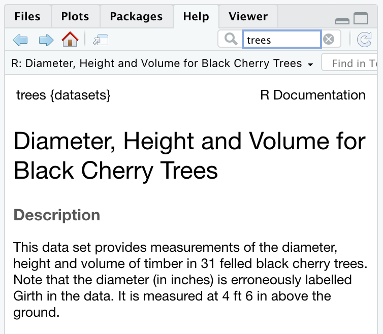

trees icon

# OBJECTS & DATA

type: section

Everything is an object in R!

We’ll be creating a lot of them…

Especially objects of the **`class`** data frame

# Data Types

**Numeric**

```r
my_sum <- 3+3

class(my_sum)
```

```
[1] "numeric"
```

```r
print(my_sum)
```

```
[1] 6
```

**Character**

```r
my_cat <- "Muffins"

class(my_cat)
```

```
[1] "character"
```

```r
my_cat
```

```
[1] "Muffins"
```

# Data Types Cont.

**Vector**

```r
my_vector <- c(1,2,3,4)

class(my_vector)
```

```
[1] "numeric"
```

```r
print(my_vector)
```

```
[1] 1 2 3 4
```

```r
my_list <- c(1,"Muffins", 3)

class(my_list)
```

```
[1] "character"
```

```r
my_list
```

```
[1] "1"       "Muffins" "3"
```

# Data Types Cont.

**Matrix**

```r
my_matrix <- matrix(1:9, nrow = 3, ncol = 3)

print(my_matrix)
```

```
     [,1] [,2] [,3]
[1,]    1    4    7
[2,]    2    5    8
[3,]    3    6    9
```

**Data Frame**

```r
my_df <- trees

head(my_df)
```

```
  Girth Height Volume
1   8.3     70   10.3
2   8.6     65   10.3
3   8.8     63   10.2
4  10.5     72   16.4
5  10.7     81   18.8
6  10.8     83   19.7
```

# Data Frame Example

title: false

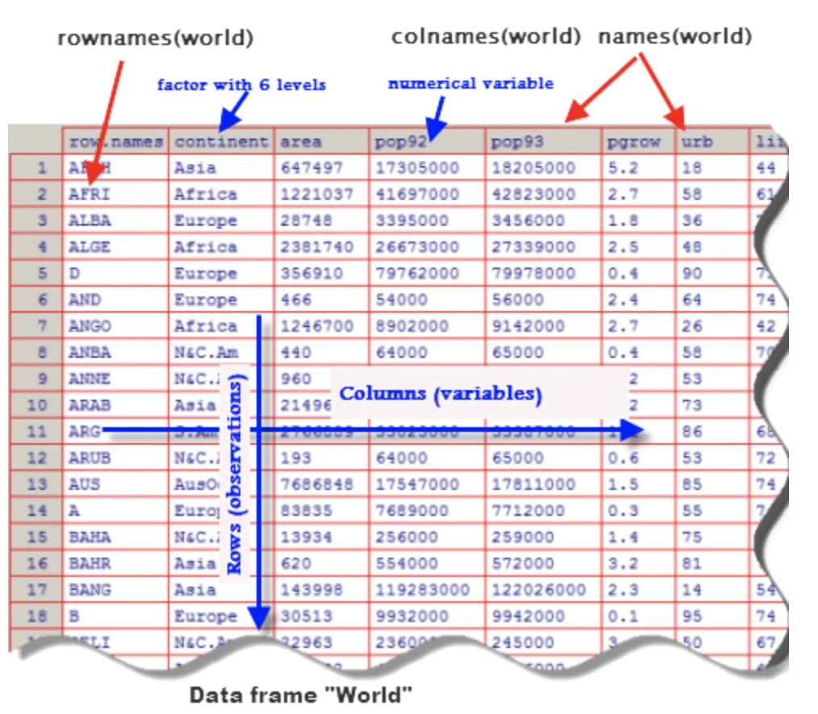

project icon

# Objects Concluded

Aside from being a certain *class*, objects can have have other attributes, such column names and dimensions:

```r
colnames(my_df)
```

```
[1] "Girth"  "Height" "Volume"
```

```r
dim(my_df)
```

```
[1] 31  3
```

And can even be used with operators! Try this:

```r
my_sum * my_matrix
```

# FUNCTIONS

type: section

Functions are pre-packaged pieces of code that (typically) start with a verb, followed by objects or inputs in parentheses called “arguments”:

```r
do_this(to_this)
do_that(to_this, to_that, with_those)
```

# Let’s make a function!

Basic template for creating a function:

```r
name_of_function <- function(argument_1, argument_2){
    code_that_does_something
    code_that_does_something_else
}
```

Try making this basic addition function:

```r
add_numbers <- function(number_1, number_2) {
    number_1 + number_2
}
```

# Let’s test it!

Use your new function to add 1 and 2:

```r
add_numbers(1, 2)
```

```
[1] 3
```

What happens if we try add the objects we created earlier?

```r
add_numbers(my_sum, my_matrix)
```

What about these objects?

```r
add_numbers(my_sum, my_list)
```

# Most popular (non-base R) functions on GitHub

title:

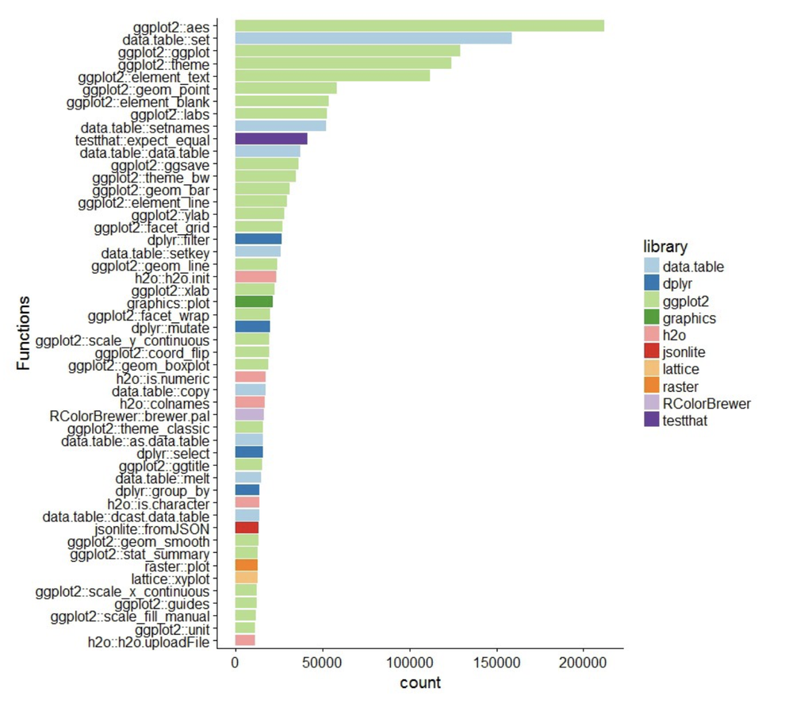